# Ago1_known_novel_miRNA_target_enrichment_in_peaks

## Search top 10 most abundant known miRNA family 6mers in cells

```r
#all peak ranges
res <- annotatePeaksWithPatterns(peaks=allGR,
                                  fasta="/Users/kathryn/mirdeep2_master/Aedes-aegypti-LVP_AGWG_CHROMOSOMES_AaegL5.fa",
                                patterns="/Users/kathryn/Reprocess_all_paper_datasets/Rmds_to_upload/To_upload/top10_cells_Ago1_known_fam_rn.fa",
                                  resize=406,
                                  add5=1,
                                  add3=1,
                                  verbose=TRUE)
```

```
## Reading in peaks.......done
## Read in 98398 peaks
## Indexing FASTA......done
## Aligning seqlevels across peaks and FASTA......done
## Removing invalid peaks which are outside contig boundaries...
```

```
## ...done
## Removed in 0 peaks
## Retrieving sequence from under peaks.......done
## Retrieving patterns to search for.......done
## Read in 10 patterns
## Searching for 10 patterns in peaks....
## Search for ATACTC
## Search for CCGTCC
## Search for CTAGTC
## Search for GAGATT
## Search for GATATT
## Search for GATCTC
## Search for GTACAA
## Search for GTGTTC
## Search for TACCTG
## Search for TGTGAT
## ....finished search
```

```r
res <- res[[1]]
res <- rbindlist(res)
res$group <- paste0(res$SeqExtended, "_", res$siteOfPattern)
res$startOfPmatch <- as.numeric(res$startOfPmatch)
res$filt <- duplicated(res$group)
res_Ago1_known <- subset(res, res$filt == FALSE)

#control ranges
res_Ago1_known_ctrl <- annotatePeaksWithPatterns(peaks=allctrlGR,
                              fasta="/Users/kathryn/mirdeep2_master/Aedes-aegypti-LVP_AGWG_CHROMOSOMES_AaegL5.fa",
patterns="/Users/kathryn/Reprocess_all_paper_datasets/Rmds_to_upload/To_upload/top10_cells_Ago1_known_fam_rn.fa",
                                  resize=406,
                                  add5=1,
                                  add3=1,
                                  verbose=TRUE)
```

```
## Reading in peaks.......done
## Read in 98398 peaks
## Indexing FASTA......done
## Aligning seqlevels across peaks and FASTA...
```

[output not shown]

```
## ...done
## Removing invalid peaks which are outside contig boundaries...
```

[output not shown]

```
## ...done
## Removed in 0 peaks
## Retrieving sequence from under peaks.......done
## Retrieving patterns to search for.......done
## Read in 10 patterns
## Searching for 10 patterns in peaks....
## Search for ATACTC
## Search for CCGTCC
## Search for CTAGTC
## Search for GAGATT
## Search for GATATT
## Search for GATCTC
## Search for GTACAA
## Search for GTGTTC
## Search for TACCTG
## Search for TGTGAT
## ....finished search
```

```r
res_Ago1_known_ctrl <- res_Ago1_known_ctrl[[1]]
res_Ago1_known_ctrl <- rbindlist(res_Ago1_known_ctrl)
res_Ago1_known_ctrl$group <- paste0(res_Ago1_known_ctrl$SeqExtended, "_", res_Ago1_known_ctrl$siteOfPattern)
res_Ago1_known_ctrl$startOfPmatch <- as.numeric(res_Ago1_known_ctrl$startOfPmatch)
res_Ago1_known_ctrl$filt <- duplicated(res_Ago1_known_ctrl$group)
res_Ago1_known_ctrl <- subset(res_Ago1_known_ctrl, res_Ago1_known_ctrl$filt == FALSE)

#get GRs with the same peak subset for calculating specific coverage
Ago1_Aag2_ranges <- subset(res_Ago1_known, res_Ago1_known$Aag2_Ago1_BCsample > 0 & res_Ago1_known$Aag2_Ago2_BCsample ==0 )
Ago1_Aag2_ctrl_ranges <- subset(res_Ago1_known_ctrl, res_Ago1_known_ctrl$Aag2_Ago1_BCsample > 0 & res_Ago1_known_ctrl$Aag2_Ago2_BCsample ==0 )

#subset matched patterns in peaks with support from Aag2 Ago1 reads
Ago1_Aag2_seed_known_ctrl <- subset(res_Ago1_known_ctrl$startOfPmatch, res_Ago1_known_ctrl$Aag2_Ago1_BCsample > 0 & res_Ago1_known_ctrl$Aag2_Ago2_BCsample ==0)
Ago1_Aag2_seed_known <- subset(res_Ago1_known$startOfPmatch, res_Ago1_known$Aag2_Ago1_BCsample > 0 & res_Ago1_known$Aag2_Ago2_BCsample ==0)
```

## Get coverage by position around peaks containing patterns; known miRNAs

```r
# #aegypti Ago1 known peak ranges
# Ago1_aegyptik_GR <-  GRanges(seqnames = Ago1_aegypti_ranges$seqnames.x, strand = Ago1_aegypti_ranges$strand.x,
#                           ranges = IRanges(start =Ago1_aegypti_ranges$start.x, width =Ago1_aegypti_ranges$width.x ))
#
# ToPlot_aegypti_Ago1kalt <- regionPlot(bamFile = "/Users/kathryn/Reprocess_all_paper_datasets/AaegL5_mapped/cat_aegyptiAgo1.bw",Ago1_aegyptik_GR  ,format = "bigwig")
# f <- plotRegion(ToPlot_aegypti_Ago1kalt,outliers = 0.05,groupBy = "Sample")
# aegypti_Ago1kalt <- f$data
#
# #aegypti Ago1 known control ranges
# Ago1_aegyptik_ctrlGR <-  GRanges(seqnames = Ago1_aegypti_ctrl_ranges$seqnames.x, strand = Ago1_aegypti_ctrl_ranges$strand.x,
#                              ranges = IRanges(start =Ago1_aegypti_ctrl_ranges$start.x, width =Ago1_aegypti_ctrl_ranges$width.x ))
#
# ToPlot_ctrl_aegypti_kAgo1 <- regionPlot(bamFile = "/Users/kathryn/Reprocess_all_paper_datasets/AaegL5_mapped/cat_aegyptiAgo1.bw",Ago1_aegyptik_ctrlGR,format = "bigwig")
# ctrl_aegypti_kAgo1_peaks  <- plotRegion(ToPlot_ctrl_aegypti_kAgo1,outliers = 0.05)
# ctrl_aegypti_kAgo1_peaks <- ctrl_aegypti_kAgo1_peaks$data
# ctrl_aegypti_kAgo1_peaks$Sample <- c("ctrl_peaks")
#
# aegypti_Ago1kalt  <- rbind(ctrl_aegypti_kAgo1_peaks, aegypti_Ago1kalt )
#
# #Aag2 Ago1 known peak ranges
# Ago1_Aag2k_GR <-  GRanges(seqnames = Ago1_Aag2_ranges$seqnames.x, strand = Ago1_Aag2_ranges$strand.x,
#                           ranges = IRanges(start = Ago1_Aag2_ranges$start.x, width =Ago1_Aag2_ranges$width.x ))
#
# ToPlot_Aag2_Ago1kalt <- regionPlot(bamFile = "/Users/kathryn/Reprocess_all_paper_datasets/AaegL5_mapped/cat_Aag2Ago1.bw",Ago1_Aag2k_GR ,format = "bigwig")
# f <- plotRegion(ToPlot_Aag2_Ago1kalt,outliers = 0.05,groupBy = "Sample")
# Aag2_Ago1kalt <- f$data
#
# #Aag2 Ago1 known control ranges
# Ago1_Aag2k_ctrlGR <-  GRanges(seqnames = Ago1_Aag2_ctrl_ranges$seqnames.x, strand = Ago1_Aag2_ctrl_ranges$strand.x,
#                               ranges = IRanges(start = Ago1_Aag2_ctrl_ranges$start.x, width =Ago1_Aag2_ctrl_ranges$width.x ))
#
# ToPlot_ctrl_Aag2_Ago1kalt <- regionPlot(bamFile = "/Users/kathryn/Reprocess_all_paper_datasets/AaegL5_mapped/cat_Aag2Ago1.bw",Ago1_Aag2k_ctrlGR ,format = "bigwig")
# ctrlAag2_Ago1kalt_peaks <- plotRegion(ToPlot_ctrl_Aag2_Ago1kalt ,outliers = 0.05)
# ctrlAag2_Ago1kalt_peaks <- ctrlAag2_Ago1kalt_peaks$data
# ctrlAag2_Ago1kalt_peaks$Sample <- c("ctrl_peaks")
#
# Aag2_Ago1kalt <- rbind(ctrlAag2_Ago1kalt_peaks, Aag2_Ago1kalt)
# #save(Aag2_Ago1kalt, aegypti_Ago1kalt, file="/Users/kathryn/Reprocess_all_paper_datasets/Rmds_to_upload/To_upload/knownmiRNAs.RData")
```

output file “knownmiRNAs.RData” is available on my [Github](https://github.com/kathrynrozengagnon/AGOCLIP_2020)

## Combine coverage with known miRNA pattern matches by positions and graph; Figures 5A and S4A

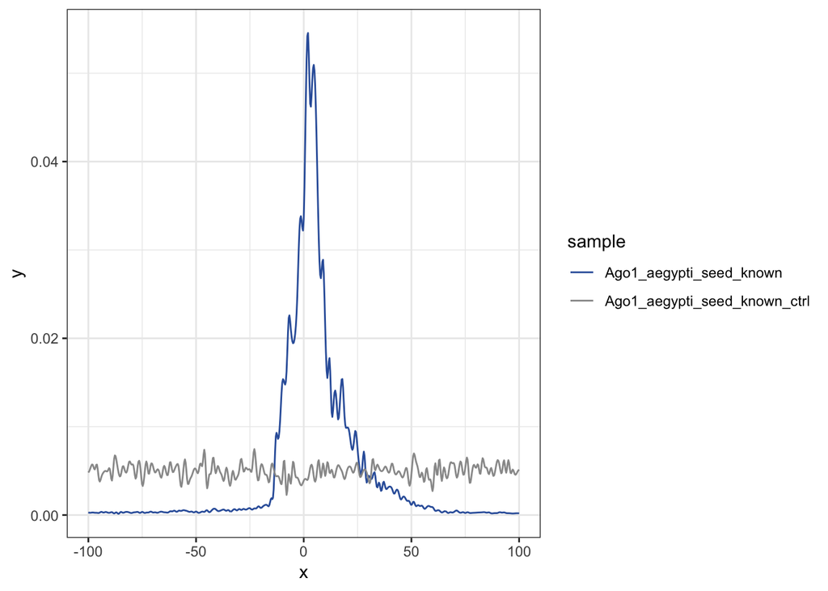

```r
load("/Users/kathryn/Reprocess_all_paper_datasets/Rmds_to_upload/To_upload/knownmiRNAs.RData")
##now combine coverage with pattern matches by position and graph
nf <- c("Aag2_Ago1kalt", "aegypti_Ago1kalt")
norm_f <- do.call("list",mget(nf))
cov <- lapply(norm_f, function(x) subset(x, x$xIndex >= 1400 & x$xIndex <=1600))
covdf <- rbindlist(cov, idcol = TRUE)
covdf$xIndex <- covdf$xIndex - 1500
col.names <- colnames(covdf)
col.names <- gsub(".id", "ranges", col.names)
col.names <- gsub("xIndex", "position", col.names)
covdf <- setNames(covdf, col.names)
cells_ago1 <- subset(covdf, covdf$ranges=="Aag2_Ago1kalt")
cells_ago1 <- subset(cells_ago1, cells_ago1$Sample=="ctrl_peaks" | cells_ago1$Sample=="cat_Aag2Ago1.bw")
aegypti_ago1 <- subset(covdf, covdf$ranges=="aegypti_Ago1kalt")
aegypti_ago1 <- subset(aegypti_ago1, aegypti_ago1$Sample=="ctrl_peaks" | aegypti_ago1$Sample=="cat_aegyptiAgo1.bw")

aegypti_ago1$merge <- ifelse(aegypti_ago1$Sample=="cat_aegyptiAgo1.bw" , paste0(aegypti_ago1$position, "Ago1_aegypti_seed_known"), paste0(aegypti_ago1$position, "Ago1_aegypti_seed_known_ctrl"))

cells_ago1$merge <- ifelse(cells_ago1$Sample=="cat_Aag2Ago1.bw" , paste0(cells_ago1$position, "Ago1_Aag2_seed_known"), paste0(cells_ago1$position, "Ago1_Aag2_seed_known_ctrl"))

#get lists of pattern seed matches and then count all together for graphing
Ago1known <- grep("_seed_known", names(.GlobalEnv),value=TRUE)
Ago1known <- grep("Ago1_", Ago1known, value=TRUE)
Ago1known <- do.call("list",mget(Ago1known))
Ago1known <- lapply(Ago1known, as.data.frame)
Ago1known <- lapply(Ago1known, setNames, nm="position")
Ago1known_counts <- lapply(Ago1known, function(x) x %>% group_by(position) %>% summarize(count=n()))
Ago1known_counts<- lapply(Ago1known_counts, function(x) subset(x, x$position <= 300 & x$position >=100))

#make master df by sample name
Ago1df <- rbindlist(Ago1known_counts, idcol = TRUE)
Ago1df$position <- Ago1df$position - 200
Aag2Ago1k <- subset(Ago1df, Ago1df$.id=="Ago1_Aag2_seed_known_ctrl" | Ago1df$.id=="Ago1_Aag2_seed_known")
Aag2Ago1k$merge <- paste0(Aag2Ago1k$position, Aag2Ago1k$.id)

aegyptiAgo1k <- subset(Ago1df, Ago1df$.id=="Ago1_aegypti_seed_known_ctrl" | Ago1df$.id=="Ago1_aegypti_seed_known")
aegyptiAgo1k$merge <- paste0(aegyptiAgo1k$position, aegyptiAgo1k$.id)

#merge coverage with pattern match counts by position
aegypti_ago1 <- merge(aegyptiAgo1k, aegypti_ago1, by="merge")
cells_ago1 <- merge(Aag2Ago1k, cells_ago1, by="merge")

aegypti_ago1 <- aegypti_ago1 %>%
  group_by(Sample) %>%
  mutate( counts_norm = (count*Score))

aegypti_ago1 <- aegypti_ago1 %>%
  group_by(Sample) %>%
  mutate(freq_norm = counts_norm/(sum(counts_norm)))

cells_ago1 <- cells_ago1 %>%
  group_by(Sample) %>%
  mutate( counts_norm = (count*Score))

cells_ago1 <-cells_ago1 %>%
  group_by(Sample) %>%
  mutate(freq_norm = counts_norm/(sum(counts_norm)))

#smooth with spline function
aegypti_ago1k  <-split(aegypti_ago1, aegypti_ago1$.id)
aegypti_ago1k  <- lapply(aegypti_ago1k, function(x) x[order(x$position.x),])
aegypti_ago1k_spline <-lapply(aegypti_ago1k, function(x) spline(x$freq_norm))
aegypti_ago1k_spline <- rbindlist(aegypti_ago1k_spline, idcol = TRUE)
aegypti_ago1k_spline$x <- aegypti_ago1k_spline$x - 101
col.names <- colnames(aegypti_ago1k_spline)
col.names <- gsub(".id", "sample", col.names)
aegypti_ago1k_spline <- setNames(aegypti_ago1k_spline, col.names)

ggplot(aegypti_ago1k_spline , aes(x = x, y = y)) +
  geom_line(aes(color = sample)) +
  scale_color_manual(values = c("#3360A9", "#999999"))  + theme_bw()
```

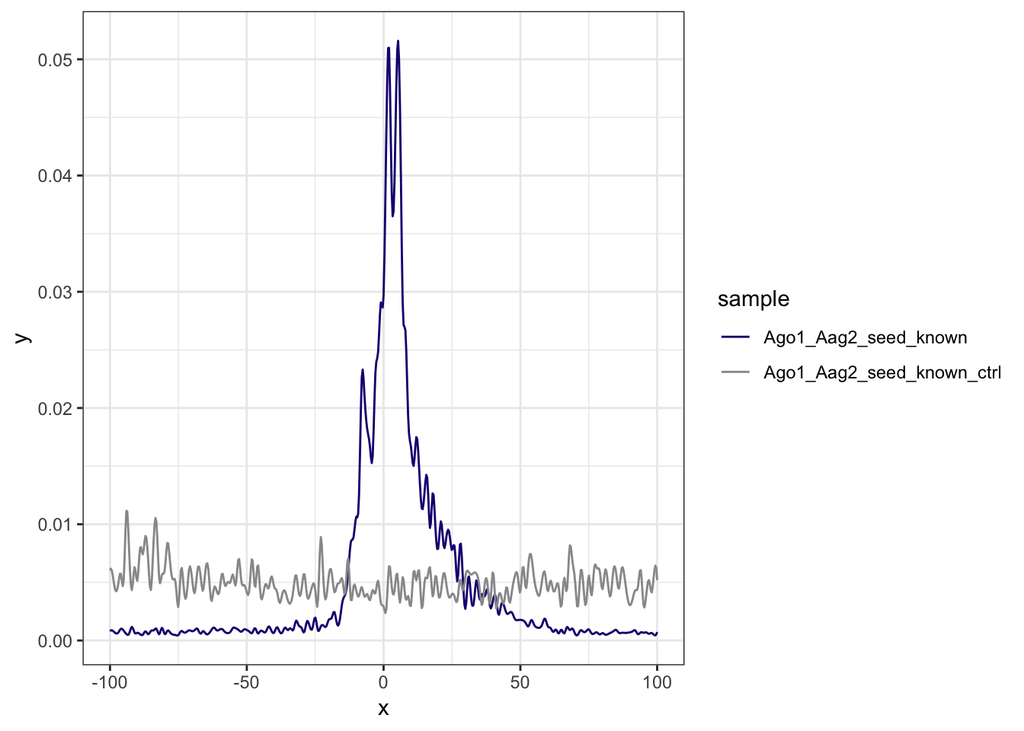

```r
cells_ago1k  <-split(cells_ago1, cells_ago1$.id)
cells_ago1k  <- lapply(cells_ago1k, function(x) x[order(x$position.x),])
cells_ago1k_spline <-lapply(cells_ago1k, function(x) spline(x$freq_norm))
cells_ago1k_spline <- rbindlist(cells_ago1k_spline, idcol = TRUE)
cells_ago1k_spline$x <- cells_ago1k_spline $x - 101
col.names <- colnames(cells_ago1k_spline)
col.names <- gsub(".id", "sample", col.names)
cells_ago1k_spline <- setNames(cells_ago1k_spline, col.names)

ggplot(cells_ago1k_spline , aes(x = x, y = y)) +
  geom_line(aes(color = sample)) +
  scale_color_manual(values = c("#1B0B80", "#999999"))  + theme_bw()
```

## Search top most abundant/targeting novel miRNA family 6mers (13 families) in mosquitoes

“aegypti_Ago1_novel_fam_rn.fa” file with 6mer target sequences of the most abundant miRNAs in cells was generated in *smallRNA_abundance_scatterplots* script and is available in my [Github](https://github.com/kathrynrozengagnon/AGOCLIP_2020/tree/master/renamed_smallRNA_fastas)

```r
#all peak ranges
res_Ago1_aegypti_novel <- annotatePeaksWithPatterns(peaks=allGR,
                                  fasta="/Users/kathryn/mirdeep2_master/Aedes-aegypti-LVP_AGWG_CHROMOSOMES_AaegL5.fa",
                                patterns="/Users/kathryn/Reprocess_all_paper_datasets/Rmds_to_upload/To_upload/aegypti_Ago1_novel_fam_rn.fa",
                                  resize=406,
                                  add5=1,
                                  add3=1,
                                  verbose=TRUE)
```

```
## Reading in peaks.......done
## Read in 98398 peaks
## Indexing FASTA......done
## Aligning seqlevels across peaks and FASTA......done
## Removing invalid peaks which are outside contig boundaries...
```

```
## ...done
## Removed in 0 peaks
## Retrieving sequence from under peaks.......done
## Retrieving patterns to search for.......done
## Read in 13 patterns
## Searching for 13 patterns in peaks....
## Search for ATGGTA
## Search for GACCTA
## Search for CGGAAT
## Search for TGGTCA
## Search for ACACCA
## Search for CCTCAC
## Search for CGGCCT
## Search for GGCCTA
## Search for TACGTA
## Search for CTACCT
## Search for ATGTCG
## Search for TATGGG
## Search for TCACTA
## ....finished search
```

```r
res_Ago1_aegypti_novel <- res_Ago1_aegypti_novel[[1]]
res_Ago1_aegypti_novel <- rbindlist(res_Ago1_aegypti_novel)
res_Ago1_aegypti_novel$group <- paste0(res_Ago1_aegypti_novel$SeqExtended, "_", res_Ago1_aegypti_novel$siteOfPattern)
res_Ago1_aegypti_novel$startOfPmatch <- as.numeric(res_Ago1_aegypti_novel$startOfPmatch)
res_Ago1_aegypti_novel$filt <- duplicated(res_Ago1_aegypti_novel$group)
res_Ago1_aegypti_novel <- subset(res_Ago1_aegypti_novel, res_Ago1_aegypti_novel$filt == FALSE)

#control ranges
res_Ago1_aegypti_novel_ctrl <- annotatePeaksWithPatterns(peaks=allctrlGR,
                              fasta="/Users/kathryn/mirdeep2_master/Aedes-aegypti-LVP_AGWG_CHROMOSOMES_AaegL5.fa",
patterns="/Users/kathryn/Reprocess_all_paper_datasets/Rmds_to_upload/To_upload/aegypti_Ago1_novel_fam_rn.fa",
                                  resize=406,
                                  add5=1,
                                  add3=1,
                                  verbose=TRUE)
```

```
## Reading in peaks.......done
## Read in 98398 peaks
## Indexing FASTA......done
## Aligning seqlevels across peaks and FASTA...
```

[output not shown]

```
## ...done
## Removing invalid peaks which are outside contig boundaries...
```

[output not shown]

```
## ...done
## Removed in 0 peaks
## Retrieving sequence from under peaks.......done
## Retrieving patterns to search for.......done
## Read in 13 patterns
## Searching for 13 patterns in peaks....
## Search for ATGGTA
## Search for GACCTA
## Search for CGGAAT
## Search for TGGTCA
## Search for ACACCA
## Search for CCTCAC
## Search for CGGCCT
## Search for GGCCTA
## Search for TACGTA
## Search for CTACCT
## Search for ATGTCG
## Search for TATGGG
## Search for TCACTA
## ....finished search
```

```r
res_Ago1_aegypti_novel_ctrl <- res_Ago1_aegypti_novel_ctrl[[1]]
res_Ago1_aegypti_novel_ctrl <- rbindlist(res_Ago1_aegypti_novel_ctrl)
res_Ago1_aegypti_novel_ctrl$group <- paste0(res_Ago1_aegypti_novel_ctrl$SeqExtended, "_", res_Ago1_aegypti_novel_ctrl$siteOfPattern)
res_Ago1_aegypti_novel_ctrl$startOfPmatch <- as.numeric(res_Ago1_aegypti_novel_ctrl$startOfPmatch)
res_Ago1_aegypti_novel_ctrl$filt <- duplicated(res_Ago1_aegypti_novel_ctrl$group)
res_Ago1_aegypti_novel_ctrl <- subset(res_Ago1_aegypti_novel_ctrl, res_Ago1_aegypti_novel_ctrl$filt == FALSE)

#get GRs with the same peak subset for calculating specific coverage
Ago1_aegypti_nranges <- subset(res_Ago1_aegypti_novel, res_Ago1_aegypti_novel$aegypti_Ago1_BCsample > 0 & res_Ago1_aegypti_novel$aegypti_Ago2_BCsample ==0)
Ago1_aegypti_ctrl_nranges <- subset(res_Ago1_aegypti_novel_ctrl, res_Ago1_aegypti_novel_ctrl$aegypti_Ago1_BCsample > 0 & res_Ago1_aegypti_novel_ctrl$aegypti_Ago2_BCsample ==0)

#subset matched patterns in peaks with support from aegypti Ago1 reads
Ago1_aegypti_seed_novel_ctrl <- subset(res_Ago1_aegypti_novel_ctrl$startOfPmatch, res_Ago1_aegypti_novel_ctrl$aegypti_Ago1_BCsample > 0 & res_Ago1_aegypti_novel_ctrl$aegypti_Ago2_BCsample ==0)
Ago1_aegypti_seed_novel <- subset(res_Ago1_aegypti_novel$startOfPmatch, res_Ago1_aegypti_novel$aegypti_Ago1_BCsample > 0 & res_Ago1_aegypti_novel$aegypti_Ago2_BCsample ==0)
```

## Search top most abundant/targeting novel miRNA family 6mers (15 families) in Aag2 cells

“cells_Ago1_novel_fam_rn.fa” file with 6mer target sequences of the most abundant miRNAs in cells was generated in *smallRNA_abundance_scatterplots* script and is available in my [Github](https://github.com/kathrynrozengagnon/AGOCLIP_2020/tree/master/renamed_smallRNA_fastas)

```r
#all peak ranges
res_Ago1_cells_novel <- annotatePeaksWithPatterns(peaks=allGR,
                              fasta="/Users/kathryn/mirdeep2_master/Aedes-aegypti-LVP_AGWG_CHROMOSOMES_AaegL5.fa",
patterns="/Users/kathryn/Reprocess_all_paper_datasets/Rmds_to_upload/To_upload/cells_Ago1_novel_fam_rn.fa",
                                  resize=406,
                                  add5=1,
                                  add3=1,
                                  verbose=TRUE)
```

```
## Reading in peaks.......done
## Read in 98398 peaks
## Indexing FASTA......done
## Aligning seqlevels across peaks and FASTA......done
## Removing invalid peaks which are outside contig boundaries...
```

```
## ...done
## Removed in 0 peaks
## Retrieving sequence from under peaks.......done
## Retrieving patterns to search for.......done
## Read in 15 patterns
## Searching for 15 patterns in peaks....
## Search for AAATCC
## Search for ATGGTA
## Search for GTAGGA
## Search for GTGGGA
## Search for ATGGAC
## Search for CCAGGA
## Search for GACCTA
## Search for CCAATC
## Search for CGGAAT
## Search for TGGTCA
## Search for AATCCA
## Search for ATAAAT
```

```
## Search for TGCCGT
## Search for CTACCT
## Search for TATGGG
## ....finished search
```

```r
res_Ago1_cells_novel <- res_Ago1_cells_novel[[1]]
res_Ago1_cells_novel <- rbindlist(res_Ago1_cells_novel)
res_Ago1_cells_novel$group <- paste0(res_Ago1_cells_novel$SeqExtended, "_", res_Ago1_cells_novel$siteOfPattern)
res_Ago1_cells_novel$startOfPmatch <- as.numeric(res_Ago1_cells_novel$startOfPmatch)
res_Ago1_cells_novel$filt <- duplicated(res_Ago1_cells_novel$group)
res_Ago1_cells_novel <- subset(res_Ago1_cells_novel, res_Ago1_cells_novel$filt == FALSE)

#control ranges
res_Ago1_cells_novel_ctrl <- annotatePeaksWithPatterns(peaks=allctrlGR,
                              fasta="/Users/kathryn/mirdeep2_master/Aedes-aegypti-LVP_AGWG_CHROMOSOMES_AaegL5.fa",
patterns="/Users/kathryn/Reprocess_all_paper_datasets/Rmds_to_upload/To_upload/cells_Ago1_novel_fam_rn.fa",
                                  resize=406,
                                  add5=1,
                                  add3=1,
                                  verbose=TRUE)
```

```
## Reading in peaks.......done
## Read in 98398 peaks
## Indexing FASTA......done
## Aligning seqlevels across peaks and FASTA...
```

[output not shown]

```
## ...done
## Removing invalid peaks which are outside contig boundaries...
```

[output not shown]

```
## ...done
## Removed in 0 peaks
## Retrieving sequence from under peaks.......done
## Retrieving patterns to search for.......done
## Read in 15 patterns
## Searching for 15 patterns in peaks....
## Search for AAATCC
## Search for ATGGTA
## Search for GTAGGA
## Search for GTGGGA
## Search for ATGGAC
## Search for CCAGGA
## Search for GACCTA
## Search for CCAATC
## Search for CGGAAT
## Search for TGGTCA
## Search for AATCCA
## Search for ATAAAT
## Search for TGCCGT
## Search for CTACCT
## Search for TATGGG
## ....finished search
```

```r
res_Ago1_cells_novel_ctrl <- res_Ago1_cells_novel_ctrl[[1]]
res_Ago1_cells_novel_ctrl <- rbindlist(res_Ago1_cells_novel_ctrl)
res_Ago1_cells_novel_ctrl$group <- paste0(res_Ago1_cells_novel_ctrl$SeqExtended, "_", res_Ago1_cells_novel_ctrl$siteOfPattern)
res_Ago1_cells_novel_ctrl$startOfPmatch <- as.numeric(res_Ago1_cells_novel_ctrl$startOfPmatch)
res_Ago1_cells_novel_ctrl$filt <- duplicated(res_Ago1_cells_novel_ctrl$group)
res_Ago1_cells_novel_ctrl <- subset(res_Ago1_cells_novel_ctrl, res_Ago1_cells_novel_ctrl$filt == FALSE)


#get GRs with the same peak subset for calculating specific coverage
Ago1_Aag2_nranges <- subset(res_Ago1_cells_novel, res_Ago1_cells_novel$Aag2_Ago1_BCsample > 0 & res_Ago1_cells_novel$Aag2_Ago2_BCsample == 0 )
Ago1_Aag2_ctrl_nranges <- subset(res_Ago1_cells_novel_ctrl, res_Ago1_cells_novel_ctrl$Aag2_Ago1_BCsample > 0 & res_Ago1_cells_novel_ctrl$Aag2_Ago2_BCsample == 0 )

#subset matched patterns in peaks with support from Aag2 Ago1 reads
Ago1_Aag2_seed_novel_ctrl <- subset(res_Ago1_cells_novel_ctrl$startOfPmatch, res_Ago1_cells_novel_ctrl$Aag2_Ago1_BCsample> 0 & res_Ago1_cells_novel_ctrl$Aag2_Ago2_BCsample ==0)
Ago1_Aag2_seed_novel <- subset(res_Ago1_cells_novel$startOfPmatch, res_Ago1_cells_novel$Aag2_Ago1_BCsample > 0 & res_Ago1_cells_novel$Aag2_Ago2_BCsample == 0 )
```

## Get coverage by position around peaks containing patterns; novel miRNAs

```r
# #aegypti Ago1 novel peak ranges
# Ago1_aegyptin_GR <-  GRanges(seqnames = Ago1_aegypti_nranges$seqnames.x, strand = Ago1_aegypti_nranges$strand.x, ranges = IRanges(start = Ago1_aegypti_nranges$start.x, width =Ago1_aegypti_nranges$width.x ))
#
# toPlot_aegypti_Ago1nalt <- regionPlot(bamFile = "/Users/kathryn/Reprocess_all_paper_datasets/AaegL5_mapped/cat_aegyptiAgo1.bw",Ago1_aegyptin_GR ,format = "bigwig")
# f <- plotRegion(toPlot_aegypti_Ago1nalt,outliers = 0.05,groupBy = "Sample")
# aegypti_Ago1nalt <- f$data
#
# #aegypti Ago1 novel control ranges
# Ago1_aegyptin_ctrlGR <-  GRanges(seqnames = Ago1_aegypti_ctrl_nranges$seqnames.x, strand = Ago1_aegypti_ctrl_nranges$strand.x,ranges = IRanges(start = Ago1_aegypti_ctrl_nranges$start.x, width =Ago1_aegypti_ctrl_nranges$width.x ))
#
# ToPlot_ctrl_aegypti_Ago1nalt <- regionPlot(bamFile = "/Users/kathryn/Reprocess_all_paper_datasets/AaegL5_mapped/cat_aegyptiAgo1.bw",Ago1_aegyptin_ctrlGR,format = "bigwig")
# ctrlaegypti_Ago1nalt_peaks <- plotRegion(ToPlot_ctrl_aegypti_Ago1nalt ,outliers = 0.05)
# ctrlaegypti_Ago1nalt_peaks <- ctrlaegypti_Ago1nalt_peaks$data
# ctrlaegypti_Ago1nalt_peaks$Sample <- c("ctrl_peaks")
#
# aegypti_Ago1nalt <- rbind(ctrlaegypti_Ago1nalt_peaks, aegypti_Ago1nalt)
#
# #Aag2 Ago1 novel peak ranges
# Ago1_Aag2n_GR <-  GRanges(seqnames = Ago1_Aag2_nranges$seqnames.x, strand = Ago1_Aag2_nranges$strand.x,
# ranges = IRanges(start = Ago1_Aag2_nranges$start.x, width =Ago1_Aag2_nranges$width.x ))
#
# ToPlot_Aag2_Ago1nalt <- regionPlot(bamFile = "/Users/kathryn/Reprocess_all_paper_datasets/AaegL5_mapped/cat_Aag2Ago1.bw",Ago1_Aag2n_GR ,format = "bigwig")
# f <- plotRegion(ToPlot_Aag2_Ago1nalt,outliers = 0.05,groupBy = "Sample")
# Aag2_Ago1nalt <- f$data
#
# #Aag2 Ago1 novel control ranges
#
# Ago1_Aag2n_ctrlGR <-  GRanges(seqnames = Ago1_Aag2_ctrl_nranges$seqnames.x, strand = Ago1_Aag2_ctrl_nranges$strand.x,ranges = IRanges(start = Ago1_Aag2_ctrl_nranges$start.x, width =Ago1_Aag2_ctrl_nranges$width.x ))
#
# ToPlot_ctrl_Aag2_Ago1nalt <- regionPlot(bamFile = "/Users/kathryn/Reprocess_all_paper_datasets/AaegL5_mapped/cat_Aag2Ago1.bw",Ago1_Aag2n_ctrlGR ,format = "bigwig")
# ctrlAag2_Ago1nalt_peaks <- plotRegion(ToPlot_ctrl_Aag2_Ago1nalt ,outliers = 0.05)
# ctrlAag2_Ago1nalt_peaks <- ctrlAag2_Ago1nalt_peaks$data
# ctrlAag2_Ago1nalt_peaks$Sample <- c("ctrl_peaks")
#
# Aag2_Ago1nalt <- rbind(ctrlAag2_Ago1nalt_peaks, Aag2_Ago1nalt)
#
# #save(Aag2_Ago1nalt, aegypti_Ago1nalt, file="/Users/kathryn/Reprocess_all_paper_datasets/Rmds_to_upload/To_upload/novelmiRNAs.RData")
```

output file “novelmiRNAs.RData” is available on my [Github](https://github.com/kathrynrozengagnon/AGOCLIP_2020)

## Combine coverage with novel miRNA pattern matches by positions and graph; Figures 5B and S4B

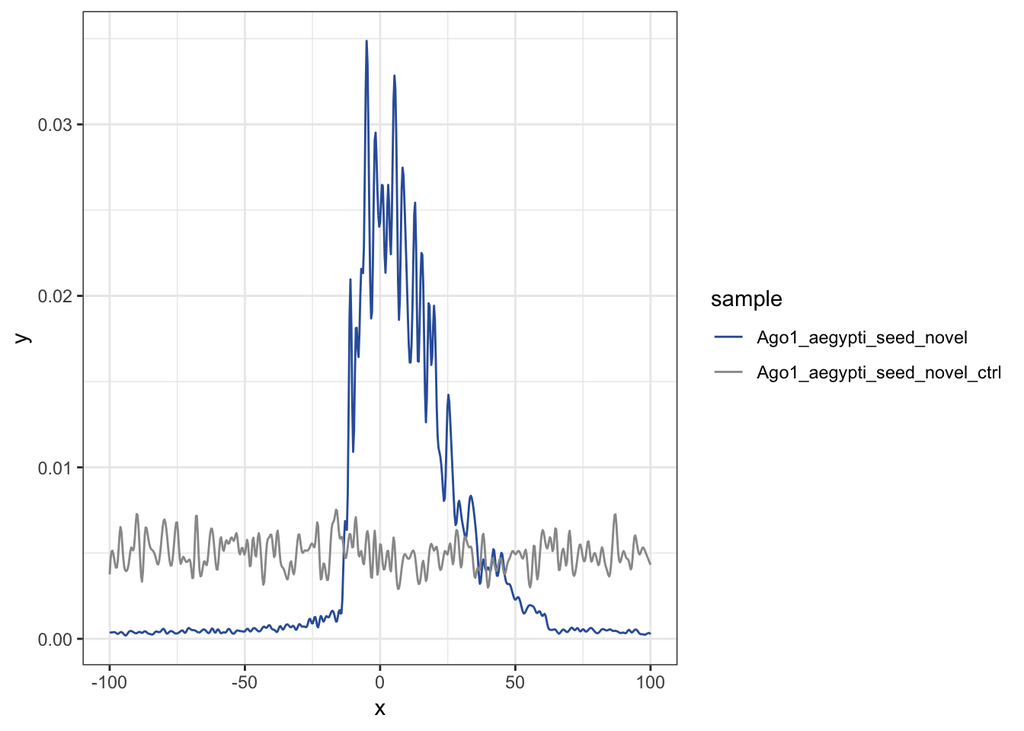

```r
load("/Users/kathryn/Reprocess_all_paper_datasets/Rmds_to_upload/To_upload/novelmiRNAs.RData")
nf <- c("Aag2_Ago1nalt", "aegypti_Ago1nalt")
norm_f <- do.call("list",mget(nf))
cov <- lapply(norm_f, function(x) subset(x, x$xIndex >= 1400 & x$xIndex <=1600))
covdf <- rbindlist(cov, idcol = TRUE)
covdf$xIndex <- covdf$xIndex - 1500
col.names <- colnames(covdf)
col.names <- gsub(".id", "ranges", col.names)
col.names <- gsub("xIndex", "position", col.names)
covdf <- setNames(covdf, col.names)

cells_ago1 <- subset(covdf, covdf$ranges=="Aag2_Ago1nalt")
aegypti_ago1 <- subset(covdf, covdf$ranges=="aegypti_Ago1nalt")

cells_ago1$merge <- ifelse(cells_ago1$Sample=="cat_Aag2Ago1.bw" , paste0(cells_ago1$position, "Ago1_Aag2_seed_novel"), paste0(cells_ago1$position, "Ago1_Aag2_seed_novel_ctrl"))

aegypti_ago1$merge <- ifelse(aegypti_ago1$Sample=="cat_aegyptiAgo1.bw" , paste0(aegypti_ago1$position, "Ago1_aegypti_seed_novel"), paste0(aegypti_ago1$position, "Ago1_aegypti_seed_novel_ctrl"))

#make list of pat matches and then count all together for graphing
Ago1novel <- grep("_seed_novel", names(.GlobalEnv),value=TRUE)
Ago1novel <- grep("Ago1_", Ago1novel, value=TRUE)
Ago1novel <- do.call("list",mget(Ago1novel))
Ago1novel <- lapply(Ago1novel, as.data.frame)
Ago1novel <- lapply(Ago1novel, setNames, nm="position")
Ago1novel_counts <- lapply(Ago1novel, function(x) x %>% group_by(position) %>% summarize(count=n()))
Ago1novel_counts <- lapply(Ago1novel_counts, function(x) subset(x, x$position <= 300 & x$position >=100))

#make master df by sample name
Ago1noveldf <- rbindlist(Ago1novel_counts, idcol = TRUE)
Ago1noveldf$position <- Ago1noveldf$position - 200
Aag2Ago1n <- subset(Ago1noveldf, Ago1noveldf$.id=="Ago1_Aag2_seed_novel_ctrl" | Ago1noveldf$.id=="Ago1_Aag2_seed_novel")
Aag2Ago1n$merge <- paste0(Aag2Ago1n$position,Aag2Ago1n$.id)

aegyptiAgo1n <- subset(Ago1noveldf, Ago1noveldf$.id=="Ago1_aegypti_seed_novel_ctrl" | Ago1noveldf$.id=="Ago1_aegypti_seed_novel")
aegyptiAgo1n$merge <- paste0(aegyptiAgo1n$position, aegyptiAgo1n$.id)

aegypti_ago1 <- merge(aegyptiAgo1n, aegypti_ago1, by="merge")
cells_ago1 <- merge(Aag2Ago1n, cells_ago1, by="merge")

aegypti_ago1 <- aegypti_ago1 %>%
  group_by(Sample) %>%
  mutate( counts_norm = (count*Score))

aegypti_ago1 <- aegypti_ago1 %>%
  group_by(Sample) %>%
  mutate(freq_norm = counts_norm/(sum(counts_norm)))

aegypti_ago1n  <-split(aegypti_ago1, aegypti_ago1$.id)
aegypti_ago1n  <- lapply(aegypti_ago1n, function(x) x[order(x$position.x),])
aegypti_ago1n_spline <-lapply(aegypti_ago1n, function(x) spline(x$freq_norm))
aegypti_ago1n_spline <- rbindlist(aegypti_ago1n_spline, idcol = TRUE)
aegypti_ago1n_spline$x <- aegypti_ago1n_spline$x - 101
col.names <- colnames(aegypti_ago1n_spline)
col.names <- gsub(".id", "sample", col.names)
aegypti_ago1n_spline <- setNames(aegypti_ago1n_spline, col.names)

ggplot(aegypti_ago1n_spline , aes(x = x, y = y)) +
  geom_line(aes(color = sample)) +
  scale_color_manual(values = c("#3360A9", "#999999")) + theme_bw()
```

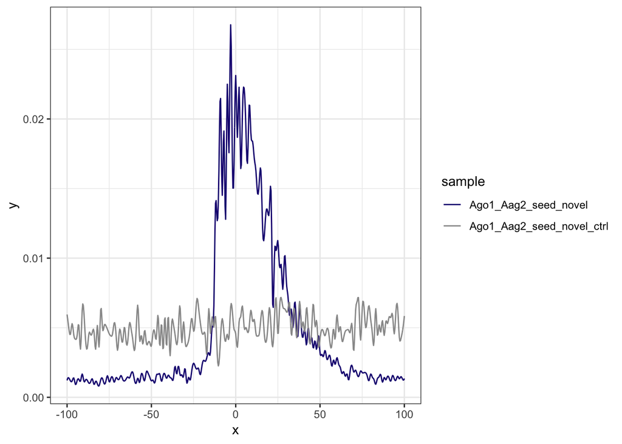

```r
cells_ago1 <- cells_ago1 %>%
  group_by(Sample) %>%
  mutate( counts_norm = (count*Score))

cells_ago1 <-cells_ago1 %>%
  group_by(Sample) %>%
  mutate(freq_norm = counts_norm/(sum(counts_norm)))

cells_ago1n <-split(cells_ago1, cells_ago1$.id)
cells_ago1n <- lapply(cells_ago1n, function(x) x[order(x$position.x),])
cells_ago1n_spline <-lapply(cells_ago1n, function(x) spline(x$freq_norm))
cells_ago1n_spline <- rbindlist(cells_ago1n_spline, idcol = TRUE)
cells_ago1n_spline$x <- cells_ago1n_spline $x - 101
col.names <- colnames(cells_ago1n_spline)
col.names <- gsub(".id", "sample", col.names)
cells_ago1n_spline <- setNames(cells_ago1n_spline, col.names)

ggplot(cells_ago1n_spline , aes(x = x, y = y)) +
  geom_line(aes(color = sample)) +
  scale_color_manual(values = c("#1B0B80", "#999999")) + theme_bw()
```

## Search for known miRNA families have similar abundance to top novel miRNAs in mosquitoes

“known_miRNAs_novelab_mos_fam_rn.fa” file with 6mer target sequences of known miRNAs of similar abundance as the most abundant novel miRNAs in mosquitoes was generated in *smallRNA_abundance_scatterplots* script and is available in my [Github](https://github.com/kathrynrozengagnon/AGOCLIP_2020/tree/master/renamed_smallRNA_fastas)

```r
 #all peak ranges
res_Ago1_av_known <- annotatePeaksWithPatterns(peaks=allGR,
                                  fasta="/Users/kathryn/mirdeep2_master/Aedes-aegypti-LVP_AGWG_CHROMOSOMES_AaegL5.fa",
                                patterns="/Users/kathryn/Reprocess_all_paper_datasets/Rmds_to_upload/To_upload/known_miRNAs_novelab_mos_fam_rn.fa",
                                  resize=406,
                                  add5=1,
                                  add3=1,
                                  verbose=TRUE)
```

```
## Reading in peaks.......done
## Read in 98398 peaks
## Indexing FASTA......done
## Aligning seqlevels across peaks and FASTA......done
## Removing invalid peaks which are outside contig boundaries...
```

```
## ...done
## Removed in 0 peaks
## Retrieving sequence from under peaks.......done
## Retrieving patterns to search for.......done
## Read in 6 patterns
## Searching for 6 patterns in peaks....
## Search for GATATT
## Search for GCACAA
## Search for TAAACC
## Search for TACCTC
## Search for TCAGGG
## Search for TGCCTT
## ....finished search
```

```r
res_Ago1_av_known <- res_Ago1_av_known[[1]]
res_Ago1_av_known <- rbindlist(res_Ago1_av_known)
res_Ago1_av_known$group <- paste0(res_Ago1_av_known$SeqExtended, "_", res_Ago1_av_known$siteOfPattern)
res_Ago1_av_known$startOfPmatch <- as.numeric(res_Ago1_av_known$startOfPmatch)
res_Ago1_av_known$filt <- duplicated(res_Ago1_av_known$group)
res_Ago1_av_known <- subset(res_Ago1_av_known, res_Ago1_av_known$filt == FALSE)

#control ranges
res_Ago1_av_known_ctrl <- annotatePeaksWithPatterns(peaks=allctrlGR,
                              fasta="/Users/kathryn/mirdeep2_master/Aedes-aegypti-LVP_AGWG_CHROMOSOMES_AaegL5.fa",
patterns="/Users/kathryn/Reprocess_all_paper_datasets/Rmds_to_upload/To_upload/known_miRNAs_novelab_mos_fam_rn.fa",
                                  resize=406,
                                  add5=1,
                                  add3=1,
                                  verbose=TRUE)
```

```
## Reading in peaks.......done
## Read in 98398 peaks
## Indexing FASTA......done
## Aligning seqlevels across peaks and FASTA...
```

[output not shown]

```
## ...done
## Removing invalid peaks which are outside contig boundaries...
```

[output not shown]

```
## ...done
## Removed in 0 peaks
## Retrieving sequence from under peaks.......done
## Retrieving patterns to search for.......done
## Read in 6 patterns
## Searching for 6 patterns in peaks....
## Search for GATATT
## Search for GCACAA
## Search for TAAACC
## Search for TACCTC
## Search for TCAGGG
## Search for TGCCTT
## ....finished search
```

```r
res_Ago1_av_known_ctrl <- res_Ago1_av_known_ctrl[[1]]
res_Ago1_av_known_ctrl <- rbindlist(res_Ago1_av_known_ctrl)
res_Ago1_av_known_ctrl$group <- paste0(res_Ago1_av_known_ctrl$SeqExtended, "_", res_Ago1_av_known_ctrl$siteOfPattern)
res_Ago1_av_known_ctrl$startOfPmatch <- as.numeric(res_Ago1_av_known_ctrl$startOfPmatch)
res_Ago1_av_known_ctrl$filt <- duplicated(res_Ago1_av_known_ctrl$group)
res_Ago1_av_known_ctrl <- subset(res_Ago1_av_known_ctrl, res_Ago1_av_known_ctrl$filt == FALSE)

#subset matched patterns in peaks with support from aegypti Ago1 reads
res_Ago1_av_aegypti_known_ctrl <- subset(res_Ago1_av_known_ctrl$startOfPmatch, res_Ago1_av_known_ctrl$aegypti_Ago1_BCsample > 0 & res_Ago1_av_known_ctrl$aegypti_Ago2_BCsample == 0)
res_Ago1_av_aegypti_known <- subset(res_Ago1_av_known$startOfPmatch, res_Ago1_av_known$aegypti_Ago1_BCsample > 0 & res_Ago1_av_known$aegypti_Ago2_BCsample == 0)

#get GRs with the same peak subset for calculating specific coverage
res_Ago1_av_aegypti_known_ctrl_pats <- subset(res_Ago1_av_known_ctrl, res_Ago1_av_known_ctrl$aegypti_Ago1_BCsample > 0 & res_Ago1_av_known_ctrl$aegypti_Ago2_BCsample == 0)
res_Ago1_av_aegypti_known_pats <- subset(res_Ago1_av_known, res_Ago1_av_known$aegypti_Ago1_BCsample > 0 & res_Ago1_av_known$aegypti_Ago2_BCsample == 0)
```

## Search for known miRNA families have similar abundance to top novel miRNAs in Aag2 cells

“known_miRNAs_novelab_cells_fam_rn.fa” file with 6mer target sequences of known miRNAs of similar abundance as the most abundant novel miRNAs in cells was generated in *smallRNA_abundance_scatterplots* script and is available in my [Github](https://github.com/kathrynrozengagnon/AGOCLIP_2020/tree/master/renamed_smallRNA_fastas)

```r
#all peak ranges
res_Ago1_av_known <- annotatePeaksWithPatterns(peaks=allGR,
                                  fasta="/Users/kathryn/mirdeep2_master/Aedes-aegypti-LVP_AGWG_CHROMOSOMES_AaegL5.fa",
                                patterns="/Users/kathryn/Reprocess_all_paper_datasets/Rmds_to_upload/To_upload/known_miRNAs_novelab_cells_fam_rn.fa",
                                  resize=406,
                                  add5=1,
                                  add3=1,
                                  verbose=TRUE)
```

```
## Reading in peaks.......done
## Read in 98398 peaks
## Indexing FASTA......done
## Aligning seqlevels across peaks and FASTA......done
## Removing invalid peaks which are outside contig boundaries...
```

```
## ...done
## Removed in 0 peaks
## Retrieving sequence from under peaks.......done
## Retrieving patterns to search for.......done
## Read in 4 patterns
## Searching for 4 patterns in peaks....
## Search for ACGCTT
## Search for AGTATT
## Search for AGTGAG
## Search for TGGTAA
## ....finished search
```

```r
res_Ago1_av_known <- res_Ago1_av_known[[1]]
res_Ago1_av_known <- rbindlist(res_Ago1_av_known)
res_Ago1_av_known$group <- paste0(res_Ago1_av_known$SeqExtended, "_", res_Ago1_av_known$siteOfPattern)
res_Ago1_av_known$startOfPmatch <- as.numeric(res_Ago1_av_known$startOfPmatch)
res_Ago1_av_known$filt <- duplicated(res_Ago1_av_known$group)
res_Ago1_av_known <- subset(res_Ago1_av_known, res_Ago1_av_known$filt == FALSE)


#control ranges
res_Ago1_av_known_ctrl <- annotatePeaksWithPatterns(peaks=allctrlGR,
                              fasta="/Users/kathryn/mirdeep2_master/Aedes-aegypti-LVP_AGWG_CHROMOSOMES_AaegL5.fa",
patterns="/Users/kathryn/Reprocess_all_paper_datasets/Rmds_to_upload/To_upload/known_miRNAs_novelab_cells_fam_rn.fa",
                                  resize=406,
                                  add5=1,
                                  add3=1,
                                  verbose=TRUE)
```

```
## Reading in peaks.......done
## Read in 98398 peaks
## Indexing FASTA......done
## Aligning seqlevels across peaks and FASTA...
```

[output not shown]

```
## ...done
## Removing invalid peaks which are outside contig boundaries...
```

[output not shown]

```
## ...done
## Removed in 0 peaks
## Retrieving sequence from under peaks.......done
## Retrieving patterns to search for.......done
## Read in 4 patterns
## Searching for 4 patterns in peaks....
## Search for ACGCTT
## Search for AGTATT
## Search for AGTGAG
## Search for TGGTAA
## ....finished search
```

```r
res_Ago1_av_known_ctrl <- res_Ago1_av_known_ctrl[[1]]
res_Ago1_av_known_ctrl <- rbindlist(res_Ago1_av_known_ctrl)
res_Ago1_av_known_ctrl$group <- paste0(res_Ago1_av_known_ctrl$SeqExtended, "_", res_Ago1_av_known_ctrl$siteOfPattern)
res_Ago1_av_known_ctrl$startOfPmatch <- as.numeric(res_Ago1_av_known_ctrl$startOfPmatch)
res_Ago1_av_known_ctrl$filt <- duplicated(res_Ago1_av_known_ctrl$group)
res_Ago1_av_known_ctrl <- subset(res_Ago1_av_known_ctrl, res_Ago1_av_known_ctrl$filt == FALSE)

#subset matched patterns in peaks with support from Aag2 Ago1 reads
res_Ago1_av_cells_known_ctrl <- subset(res_Ago1_av_known_ctrl$startOfPmatch, res_Ago1_av_known_ctrl$Aag2_Ago1_BCsample > 0 & res_Ago1_av_known_ctrl$Aag2_Ago2_BCsample == 0)
res_Ago1_av_cells_known <- subset(res_Ago1_av_known$startOfPmatch, res_Ago1_av_known$Aag2_Ago1_BCsample > 0 & res_Ago1_av_known$Aag2_Ago2_BCsample == 0)

#get GRs with the same peak subset for calculating specific coverage
res_Ago1_av_cells_known_ctrl_pats <- subset(res_Ago1_av_known_ctrl, res_Ago1_av_known_ctrl$Aag2_Ago1_BCsample > 0 & res_Ago1_av_known_ctrl$Aag2_Ago2_BCsample == 0)
res_Ago1_av_cells_known_pats <- subset(res_Ago1_av_known, res_Ago1_av_known$Aag2_Ago1_BCsample > 0 & res_Ago1_av_known$Aag2_Ago2_BCsample == 0)
```

## Get coverage by position around peaks containing patterns; known miRNAs with similar abundance to top novel miRNAs

```r
# #aegypti Ago1 known (novel ab) peak ranges
# Ago1_aegypti_avk_GR <-  GRanges(seqnames = res_Ago1_av_aegypti_known_pats$seqnames.x, strand = res_Ago1_av_aegypti_known_pats$strand.x, ranges = IRanges(start = res_Ago1_av_aegypti_known_pats$start.x, width =res_Ago1_av_aegypti_known_pats$width.x ))
#
# ToPlot_ctrl_Ago1_aegypti_avk <- regionPlot(bamFile = "/Users/kathryn/Reprocess_all_paper_datasets/AaegL5_mapped/cat_aegyptiAgo1.bw",Ago1_aegypti_avk_GR,format = "bigwig")
# aegypti_Ago1_avk <- plotRegion(ToPlot_ctrl_Ago1_aegypti_avk  ,outliers = 0.05)
# aegypti_Ago1_avk <- aegypti_Ago1_avk$data
#
# #aegypti Ago1 known (novel ab) control ranges
# Ago1_aegypti_avk_ctrlGR <-  GRanges(seqnames = res_Ago1_av_aegypti_known_ctrl_pats$seqnames.x, strand = res_Ago1_av_aegypti_known_ctrl_pats$strand.x,ranges = IRanges(start = res_Ago1_av_aegypti_known_ctrl_pats$start.x, width =res_Ago1_av_aegypti_known_ctrl_pats$width.x ))
#
# toPlot_aegypti_avk_ctrl <- regionPlot(bamFile = "/Users/kathryn/Reprocess_all_paper_datasets/AaegL5_mapped/cat_aegyptiAgo1.bw",Ago1_aegypti_avk_ctrlGR ,format = "bigwig")
# aegypti_Ago1_avk_ctrl <- plotRegion(toPlot_aegypti_avk_ctrl,outliers = 0.05,groupBy = "Sample")
# aegypti_Ago1_avk_ctrl <- aegypti_Ago1_avk_ctrl$data
# aegypti_Ago1_avk_ctrl$Sample <- c("ctrl_peaks")
#
# aegypti_Ago1_avk <- rbind(aegypti_Ago1_avk, aegypti_Ago1_avk_ctrl)
#
# #Aag2 Ago1 known (novel ab) peak ranges
# Ago1_Aag2_avk_GR <-  GRanges(seqnames = res_Ago1_av_cells_known_pats$seqnames.x, strand = res_Ago1_av_cells_known_pats$strand.x, ranges = IRanges(start = res_Ago1_av_cells_known_pats$start.x, width =res_Ago1_av_cells_known_pats$width.x ))
#
# ToPlot_Aag2_Ago1_avk <- regionPlot(bamFile = "/Users/kathryn/Reprocess_all_paper_datasets/AaegL5_mapped/cat_Aag2Ago1.bw",Ago1_Aag2_avk_GR ,format = "bigwig")
# Aag2_Ago1_avk <- plotRegion(ToPlot_Aag2_Ago1_avk ,outliers = 0.05)
# Aag2_Ago1_avk <- Aag2_Ago1_avk$data
#
# #Aag2 Ago1 known (novel ab) control ranges
# Ago1_Aag2_avk_ctrlGR <-  GRanges(seqnames = res_Ago1_av_cells_known_ctrl_pats$seqnames.x, strand = res_Ago1_av_cells_known_ctrl_pats$strand.x, ranges = IRanges(start = res_Ago1_av_cells_known_ctrl_pats$start.x, width =res_Ago1_av_cells_known_ctrl_pats$width.x ))
#
# ToPlot_Aag2_Ago1_avk_ctrl <- regionPlot(bamFile = "/Users/kathryn/Reprocess_all_paper_datasets/AaegL5_mapped/cat_Aag2Ago1.bw",Ago1_Aag2_avk_ctrlGR ,format = "bigwig")
# f <- plotRegion(ToPlot_Aag2_Ago1_avk_ctrl,outliers = 0.05,groupBy = "Sample")
# Aag2_Ago1_avk_ctrl <- f$data
# Aag2_Ago1_avk_ctrl$Sample <- c("ctrl_peaks")
#
# Aag2_Ago1_avk <- rbind(Aag2_Ago1_avk_ctrl, Aag2_Ago1_avk)
#
# #save(Aag2_Ago1_avk, aegypti_Ago1_avk, file="/Users/kathryn/Reprocess_all_paper_datasets/Rmds_to_upload/To_upload/known_novelabmiRNAs.RData")
```

output file “known_novelabmiRNAs.RData” is available on my [Github](https://github.com/kathrynrozengagnon/AGOCLIP_2020)

## Combine coverage with known (novel abundance) miRNA pattern matches by positions and graph; Figures S4C and S4D

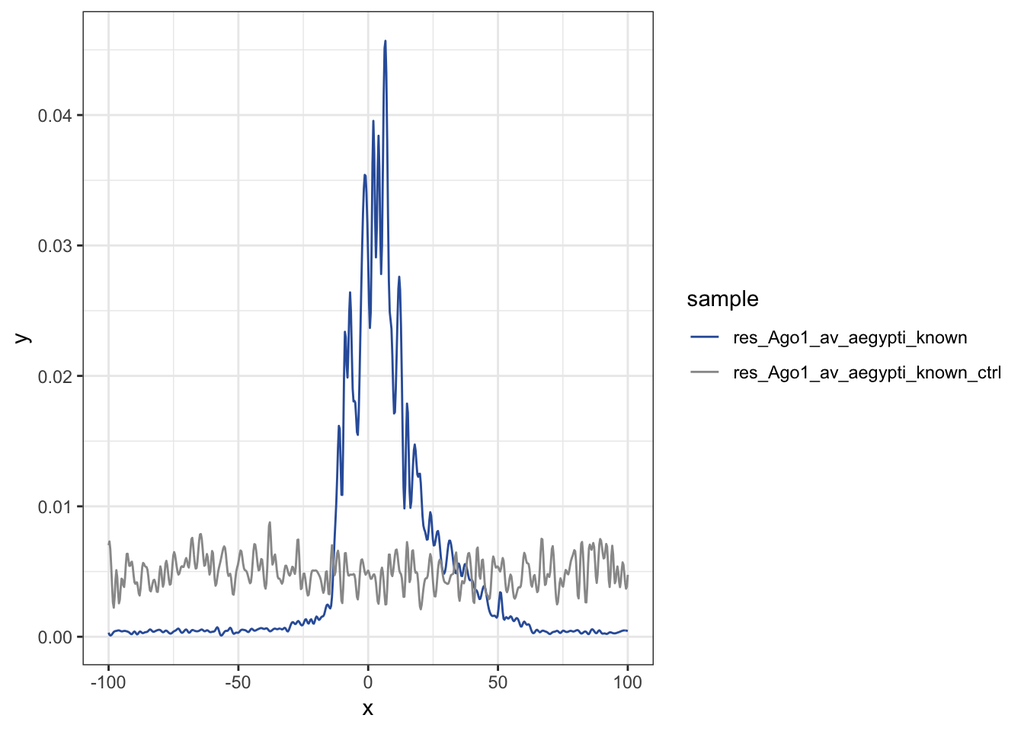

```r
load("/Users/kathryn/Reprocess_all_paper_datasets/Rmds_to_upload/To_upload/known_novelabmiRNAs.RData")
Ago1_av_known <- grep("res_Ago1_av_a", names(.GlobalEnv),value=TRUE)
Ago1_av_known <- c(Ago1_av_known, grep("res_Ago1_av_c", names(.GlobalEnv),value=TRUE))
Ago1_av_known <- grep("pats", Ago1_av_known,value=TRUE, invert = TRUE)

Ago1_av_known  <- do.call("list",mget(Ago1_av_known ))
Ago1_av_known  <- lapply(Ago1_av_known , as.data.frame)
Ago1_av_known  <- lapply(Ago1_av_known , setNames, nm="position")
Ago1_av_known_counts <- lapply(Ago1_av_known , function(x) x %>% group_by(position) %>% summarize(count=n()))
Ago1_av_known_counts <- lapply(Ago1_av_known_counts, function(x) subset(x, x$position <= 300 & x$position >=100))

Ago1avdf <- rbindlist(Ago1_av_known_counts, idcol = TRUE)
Ago1avdf$position <- Ago1avdf$position - 200
Aag2Ago1av <- subset(Ago1avdf, Ago1avdf$.id=="res_Ago1_av_cells_known_ctrl" | Ago1avdf$.id=="res_Ago1_av_cells_known")
Aag2Ago1av$merge <- paste0(Aag2Ago1av$position,Aag2Ago1av$.id)

aegyptiAgo1av <- subset(Ago1avdf, Ago1avdf$.id=="res_Ago1_av_aegypti_known_ctrl" | Ago1avdf$.id=="res_Ago1_av_aegypti_known")
aegyptiAgo1av$merge <- paste0(aegyptiAgo1av$position, aegyptiAgo1av$.id)

av <- c("Aag2_Ago1_avk", "aegypti_Ago1_avk")
norm_av <- do.call("list",mget(av))
avcov <- lapply(norm_av, function(x) subset(x, x$xIndex >= 1400 & x$xIndex <=1600))
avcovdf <- rbindlist(avcov, idcol = TRUE)
avcovdf$xIndex <- avcovdf$xIndex - 1500
col.names <- colnames(avcovdf)
col.names <- gsub(".id", "ranges", col.names)
col.names <- gsub("xIndex", "position", col.names)
avcovdf <- setNames(avcovdf, col.names)
avcells_ago1 <- subset(avcovdf, avcovdf$ranges=="Aag2_Ago1_avk")
avaegypti_ago1 <- subset(avcovdf, avcovdf$ranges=="aegypti_Ago1_avk")

avaegypti_ago1$merge <- ifelse(avaegypti_ago1$Sample=="cat_aegyptiAgo1.bw" , paste0(avaegypti_ago1$position, "res_Ago1_av_aegypti_known"), paste0(avaegypti_ago1$position, "res_Ago1_av_aegypti_known_ctrl"))

avcells_ago1$merge <- ifelse(avcells_ago1$Sample=="cat_Aag2Ago1.bw" , paste0(avcells_ago1$position, "res_Ago1_av_cells_known"), paste0(avcells_ago1$position, "res_Ago1_av_cells_known_ctrl"))

aegyptiAgo1av <- merge(aegyptiAgo1av, avaegypti_ago1, by="merge")
Aag2Ago1av <- merge(Aag2Ago1av, avcells_ago1, by="merge")

aegypti_ago1av <- aegyptiAgo1av  %>%
  group_by(Sample) %>%
  mutate( counts_norm = (count*Score))

aegypti_ago1av  <- aegypti_ago1av %>%
  group_by(Sample) %>%
  mutate(freq_norm = counts_norm/(sum(counts_norm)))

cells_ago1av <- Aag2Ago1av%>%
  group_by(Sample) %>%
  mutate( counts_norm = (count*Score))

cells_ago1av <-cells_ago1av %>%
  group_by(Sample) %>%
  mutate(freq_norm = counts_norm/(sum(counts_norm)))

aegypti_ago1av  <-split(aegypti_ago1av, aegypti_ago1av$.id)
aegypti_ago1av  <- lapply(aegypti_ago1av, function(x) x[order(x$position.x),])
aegypti_ago1av_spline <-lapply(aegypti_ago1av, function(x) spline(x$freq_norm))
aegypti_ago1av_spline <- rbindlist(aegypti_ago1av_spline, idcol = TRUE)
aegypti_ago1av_spline$x <- aegypti_ago1av_spline$x - 101
col.names <- colnames(aegypti_ago1av_spline)
col.names <- gsub(".id", "sample", col.names)
aegypti_ago1av_spline <- setNames(aegypti_ago1av_spline, col.names)

ggplot(aegypti_ago1av_spline , aes(x = x, y = y)) +
  geom_line(aes(color = sample)) +
  scale_color_manual(values = c("#3360A9", "#999999")) + theme_bw()
```

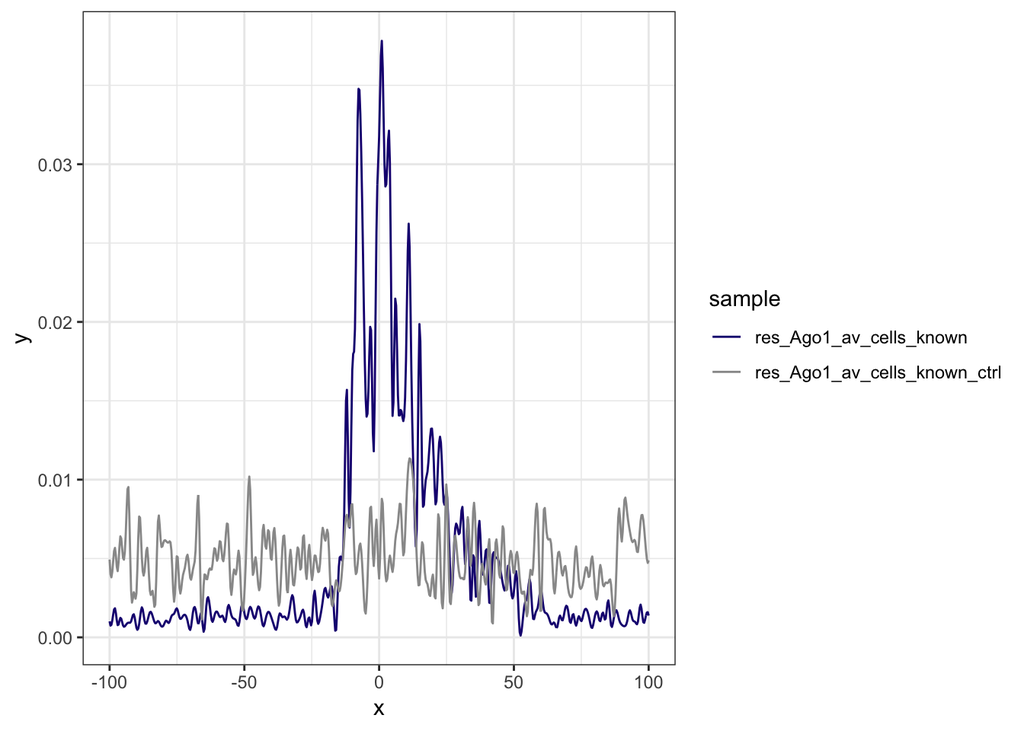

```r
cells_ago1av <-split(cells_ago1av, cells_ago1av$.id)
cells_ago1av <- lapply(cells_ago1av, function(x) x[order(x$position.x),])
cells_ago1av_spline <-lapply(cells_ago1av, function(x) spline(x$freq_norm))
cells_ago1av_spline <- rbindlist(cells_ago1av_spline, idcol = TRUE)
cells_ago1av_spline$x <- cells_ago1av_spline $x - 101
col.names <- colnames(cells_ago1av_spline)
col.names <- gsub(".id", "sample", col.names)
cells_ago1av_spline <- setNames(cells_ago1av_spline, col.names)

ggplot(cells_ago1av_spline , aes(x = x, y = y)) +
  geom_line(aes(color = sample)) +
  scale_color_manual(values = c("#1B0B80", "#999999")) + theme_bw()
```